# Predicting Case Dismissals with Machine Learning and Spark

Connor Concannon

10/30/2018

## Background

I recently heard a story on WNYC about cooling tower violations and adjudications at the New York City Office of Administrative Trials and Hearings. [According to the story](http://gothamist.com/2018/10/30/health_inspectors_bungle_thousands.php), cooling tower violations have a dismissal rate of about 90 percent, despite the link between legionnaires disease and deferred maintenance of these towers.

The story piqued my interest about the data set. In my experience, there is not much open, individual-level data about trials and case outcomes. After finding the data set on [NYC Open Data](https://data.cityofnewyork.us/City-Government/OATH-Hearings-Division-Case-Status/jz4z-kudi/data), I decided to investigate the predictors of case dismissal among all OATH appearances, not just those concerned with cooling tower violations.

This data set also presented an opportunity to expand my knowledge of [Spark](https://spark.apache.org/), an open-source distributed computing framework. In addition, Spark also has a robust machine learning API, which I will use to generate and validate my model, without bringing the data into memory or into R. This will come in handy, because the full data set is about six gigabytes, and a pain to load into memory on a laptop.

## Setup

First, I need to install dependencies and connect to a local spark instance. If this were a real production environment, or bigger data, I would be connecting to multiple machines and distributing the computations across them all. For now, I will just create a local Spark instance.

## Import Data

I downloaded a .csv of the data and saved it on my machine. Then, I used the `spark_read_csv` function to read the file into the Spark instance. Next, I pull a subset of the data I would like into R, and generate some date features, and clean up the zip code. I also omitted a handful of cases that were missing key variables. Next, I created the target variable.

```r
o <- spark_read_csv(sc, name = 'oath',
                    #path="file:///home/concannonc/spark/OATH_Hearings_Division_Case_Status sample.csv")
                     path="file:///home/c/Desktop/OATH_Hearings_Division_Case_Status sample 2017.csv")

#src_tbls(sc)

df <- o  %>%
  filter(Hearing_Status=='HEARING COMPLETED') %>%
  select(Violation_Date,Violation_Time,Issuing_Agency,
         Violation_Location_Borough_,Violation_Location_Zip_Code_,
                Hearing_Date,Hearing_Time,Charge_1_Code:Charge_1_Code_Description,
                Hearing_Result) %>%
  collect

df2 <- df %>%
  mutate(Dismissed=ifelse(Hearing_Result=='DISMISSED',1,0),
         Violation_Date=as.POSIXct(paste0(Violation_Date,' ',Violation_Time),format='%m/%d/%Y %H:%M:%S'),
         Violation_Hour=hour(Violation_Date),
         Violation_Day=day(Violation_Date),
         Violation_Year=year(Violation_Date),
         Violation_Month=month(Violation_Date)) %>%
  mutate(Violation_Location_Zip_Code=ifelse(is.na(Violation_Location_Zip_Code_),'0',Violation_Location_Zip_Code_)) %>%
  dplyr::select(-Violation_Time,-Hearing_Result) %>%
  dplyr::filter(!is.na(Violation_Hour)) %>%
  dplyr::filter(!is.na(Dismissed))


df2 <- sdf_copy_to(sc,df2,overwrite = T)
```

## Exploratory Analyses

The data set is about 125,000 violations that were written in 2017. A plot of the hearing date indicates about 400 to 600 cases were heard each day, and about 70 percent were dismissed.

A quick look at the agencies involved shows the Fire Department with a large number of violations, and a dismissal rate of just seven percent. The next closest agency is the Sanitation Department, with nearly a 98 percent dismissal rate. The cooling towers inspected by DOHMH that piqued my interest also make an appearance here - over 5,500 violations and nearly 90 percent dismissed. This matches up with what I heard on the radio, so I feel I am on the right track analyzing the data thus far.

```r
df2 %>%
  group_by(Dismissed) %>%
  tally(sort=T) %>%
  mutate(perc=round(n/sum(n)*100,2)) %>%
  collect() %>%
  kable() %>%
  kable_styling()
```

| Dismissed | n | perc |
| --- | --- | --- |
| 1 | 92394 | 73.19 |
| 0 | 33842 | 26.81 |

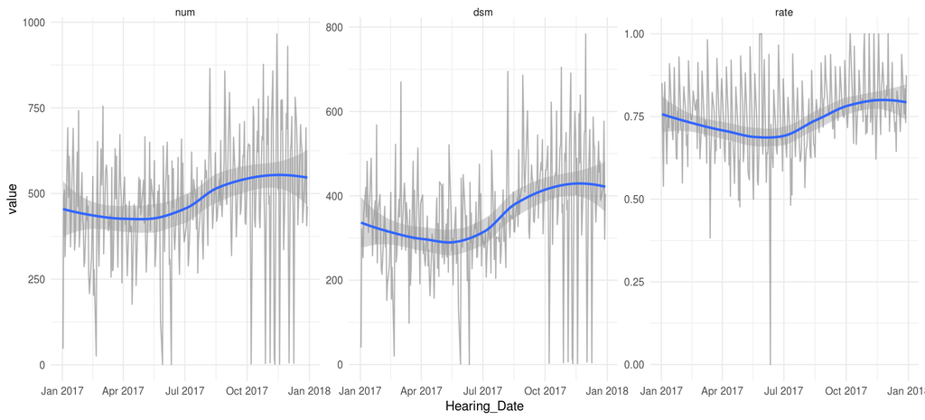

```r
df2 %>%
  group_by(Hearing_Date) %>%
  summarise(num=n(),
            dsm=sum(Dismissed)) %>%
  mutate(rate=dsm/num) %>%
  collect() %>%
  mutate(Hearing_Date=as.Date(Hearing_Date,format='%m/%d/%Y')) %>%
  filter(year(Hearing_Date)==2017) %>%
  reshape2::melt(id.vars='Hearing_Date') %>%
  ggplot(aes(Hearing_Date,value,group=variable))+
  geom_line(alpha=.3)+
  geom_smooth()+
  facet_wrap(~variable,scales='free_y')+
  theme_minimal()
```

```r
df2 %>%
  group_by(Issuing_Agency) %>%
  summarise(Number=n(),
            Dismissed=sum(Dismissed)) %>%
  mutate(`Dismissal Rate`=round(Dismissed/Number*100,2)) %>%
  ungroup() %>%
  arrange(-Number) %>%
  top_n(n=10,wt=Number) %>%
  collect() %>%
  kable(caption='Top 15 Agencies by Number of Violations') %>%
  kable_styling()
```

| Issuing_Agency | Number | Dismissed | Dismissal Rate |
| --- | --- | --- | --- |
| FIRE DEPARTMENT OF NYC | 22152 | 1571 | 7.09 |
| SANITATION OTHERS | 18832 | 18413 | 97.78 |
| DEPT. OF BUILDINGS | 18179 | 11058 | 60.83 |
| POLICE DEPARTMENT | 17137 | 16399 | 95.69 |
| DOS - ENFORCEMENT AGENTS | 12300 | 11189 | 90.97 |
| NA | 7384 | 7265 | 98.39 |
| COOLING TOWERS - DOHMH | 5587 | 5003 | 89.55 |
| SANITATION DEPT | 3733 | 3465 | 92.82 |
| PCS - DOHMH | 3713 | 2599 | 70.00 |
| DEPT OF TRANSPORTATION | 3068 | 2923 | 95.27 |

## Feature Creation and Splitting

Spark has a number of feature transformers to prepare data for machine learning tasks. Here, I transform a number of categorical features into numeric ones that are easier to pass to ML algorithms.

Next, I split the data into training and testing partitions to evaluate the performance of the algorithm.

```r
charge_indexer <- ft_string_indexer(sc, "Charge_1_Code_Description", "charge",handle_invalid = 'keep')
charge_indexer_model <- charge_indexer %>%
  ml_fit(df2)


boro_indexer <- ft_string_indexer(sc, "Violation_Location_Borough_", "borough", handle_invalid = 'keep')
boro_indexer_model <- boro_indexer %>%
  ml_fit(df2)

zip_indexer <- ft_string_indexer(sc, "Violation_Location_Zip_Code", "zip", handle_invalid = 'keep')
zip_indexer_model <- zip_indexer %>%
  ml_fit(df2)

agency_indexer <- ft_string_indexer(sc, "Issuing_Agency", "agency",handle_invalid = 'keep')
agency_indexer_model <- agency_indexer %>%
  ml_fit(df2)

partitions <- tbl(sc,"df2") %>%
  sdf_mutate(viol_hour=ft_bucketizer(Violation_Hour,c(0,8,17,24))) %>%
  sdf_partition(training=.8, test=.2, seed=813)
```

# Spark Pipeline

A [Spark pipeline](https://spark.rstudio.com/guides/pipelines/) is a mechanism to combine multiple feature transformations, pre-processing steps, and algorithms into one workflow. For example, the code here `ft_vector_assembler` concatenates multiple columns into one for ingestion by a learning algorithm. The pipeline combines all of the previous `ft_string_indexer` calls, the `ft_vector_assembler`, and defines a algorithm and target variable.

Next, I define a grid of hyper parameters for the machine learning algorithm to search. Grid search is a basic method to optimize machine learning algorithms, and will tell me about differences in performance across a (small) set of hyper-parameters.

The resulting output is a text representation of my pipeline, from the first indexer, to the final model.

```r
timeml0 <- Sys.time()

form <- as.formula(Dismissed ~ Violation_Hour + Violation_Day + Violation_Month + Violation_Year + borough +  agency + charge)


vector_assembler <- ft_vector_assembler(
  sc,
  input_cols = c("Violation_Hour", "Violation_Day", "Violation_Month", "Violation_Year","borough", "zip", "agency", "charge"),
  output_col = "features"
)


pipeline <- ml_pipeline(
  charge_indexer_model,
  boro_indexer_model,
  agency_indexer_model,
  zip_indexer_model,
  vector_assembler
) %>%
  ml_random_forest_classifier(label="Dismissed",
                              max_bins=3000)

grid <- list(
 random_forest=list(
    num_trees = c(10,20),
    max_depth = c(5,10),
    impurity = c("entropy", "gini")
  )
)

# Create the cross validator object
cv <- ml_cross_validator(
  sc, estimator = pipeline, estimator_param_maps = grid,
  evaluator = ml_binary_classification_evaluator(sc, label="Dismissed"),
  num_folds = 3, parallelism = 4
)

# Train the models
cv_model <- ml_fit(cv, partitions$training)

cv_model
```

```
## CrossValidatorModel (Transformer)
## <cross_validator_1109747b2416>
##  (Parameters -- Tuning)
##   estimator: Pipeline
##              <pipeline_11094f1a9aaf>
##   evaluator: BinaryClassificationEvaluator
##              <binary_classification_evaluator_11093017231d>
##     with metric areaUnderROC
##   num_folds: 3
##   [Tuned over 8 hyperparameter sets]
##  (Best Model)
##   PipelineModel (Transformer) with 6 stages
##   <pipeline_11094f1a9aaf>
##     Stages
##     |--1 StringIndexerModel (Transformer)
##     |    <string_indexer_11096928b550>
##     |     (Parameters -- Column Names)
##     |      input_col: Charge_1_Code_Description
##     |      output_col: charge
##     |     (Transformer Info)
##     |      labels:  chr [1:1018] "FAILURE TO CLEAN 18 INCHES INTO STREET" ...
##     |--2 StringIndexerModel (Transformer)
##     |    <string_indexer_110959eea3e1>
##     |     (Parameters -- Column Names)
##     |      input_col: Violation_Location_Borough_
##     |      output_col: borough
##     |     (Transformer Info)
##     |      labels:  chr [1:7] "MANHATTAN" "BROOKLYN" "BRONX" "QUEENS" "NOT NYC" ...
##     |--3 StringIndexerModel (Transformer)
##     |    <string_indexer_1109763097c3>
##     |     (Parameters -- Column Names)
##     |      input_col: Issuing_Agency
##     |      output_col: agency
##     |     (Transformer Info)
##     |      labels:  chr [1:49] "FIRE DEPARTMENT OF NYC" "SANITATION OTHERS" ...
##     |--4 StringIndexerModel (Transformer)
##     |    <string_indexer_110976243b51>
##     |     (Parameters -- Column Names)
##     |      input_col: Violation_Location_Zip_Code
##     |      output_col: zip
##     |     (Transformer Info)
##     |      labels:  chr [1:255] "0" "10456" "10457" "10458" "10036" "10468" ...
##     |--5 VectorAssembler (Transformer)
##     |    <vector_assembler_110975de20f5>
##     |     (Parameters -- Column Names)
##     |      input_cols: Violation_Hour, Violation_Day, Violation_Month, Violation_Year, borough, zip, agency, charge
##     |      output_col: features
##     |--6 RandomForestClassificationModel (Transformer)
##     |    <random_forest_classifier_11091b9f2fa1>
##     |     (Parameters -- Column Names)
##     |      features_col: features
##     |      label_col: Dismissed
##     |      prediction_col: prediction
##     |      probability_col: probability
##     |      raw_prediction_col: rawPrediction
##     |     (Transformer Info)
##     |      feature_importances: <function>
##     |      num_classes:  int 2
##     |      num_features:  int 8
##     |      total_num_nodes: <function>
##     |      trees: <function>
##     |      tree_weights: <function>
```

```r
Sys.time() - timeml0
```

```
## Time difference of 5.292426 mins
```

## Evaluation

Next, I ran the validation metrics on the model I previously generated. Since my grid search was not very large, or varied, there is only about a two point range in the ROC scores. Nevertheless, the model with the highest number of trees and maximum depth values scored the best, which is not surprising.

Consistent with my exploratory analysis, the agency that issued the violation is far and away the best predictor of whether it will be dismissed at the hearing. Next, the charge and zip code of the violation are predictive.

The AUC value is about .94. This model is about 91 percent accurate on the test set. Given that the base rate of dismissal is about 73 percent, this model improved dismissal predictions by about 25 percent. Not too bad!

```r
ml_validation_metrics(cv_model) %>%
  as_tibble() %>%
  arrange(-areaUnderROC) %>%
  kable(caption='Random Forest Cross Validation Metrics') %>%
  kable_styling()
```

| areaUnderROC | impurity_1 | num_trees_1 | max_depth_1 |
| --- | --- | --- | --- |
| 0.9481407 | gini | 20 | 10 |
| 0.9479418 | entropy | 20 | 10 |
| 0.9470580 | gini | 10 | 10 |
| 0.9470167 | entropy | 10 | 10 |
| 0.9302901 | entropy | 20 | 5 |
| 0.9297005 | gini | 20 | 5 |
| 0.9289471 | entropy | 10 | 5 |
| 0.9284804 | gini | 10 | 5 |

```r
feat_imp <- tibble(
  feature = unlist(vector_assembler$param_map$input_cols),
  importance = cv_model$best_model$stages[[6]]$feature_importances()
)



feat_imp %>%
  arrange(-importance) %>%
  kable(caption='Random Forest Feature Importance') %>%
  kable_styling()
```

| feature | importance |
| --- | --- |
| agency | 0.6323811 |
| charge | 0.2225332 |
| zip | 0.0840662 |
| Violation_Hour | 0.0230898 |
| Violation_Month | 0.0134444 |
| Violation_Year | 0.0132763 |
| borough | 0.0061643 |
| Violation_Day | 0.0050447 |

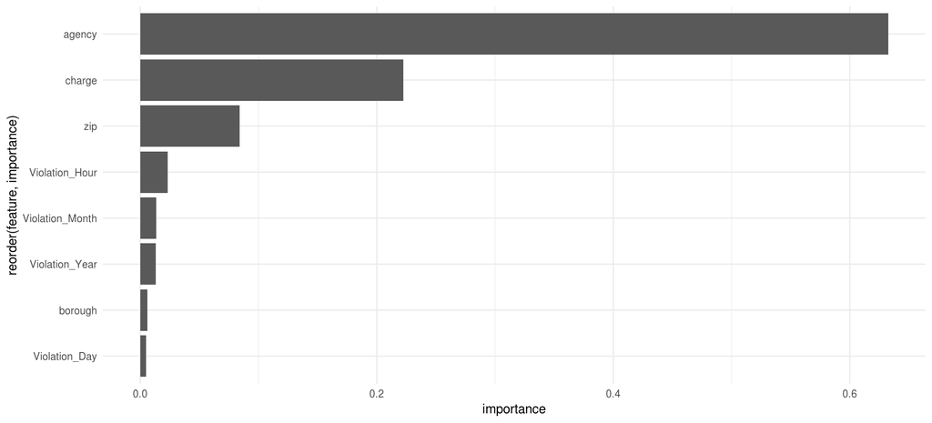

```r
feat_imp %>%
  ggplot(aes(reorder(feature,importance),importance))+geom_bar(stat='identity')+
  coord_flip()+
  theme_minimal()
```

```r
pred_rf <- sdf_predict(partitions$test,cv_model)

pred_rf %>% ml_binary_classification_evaluator(label="Dismissed",metric='areaUnderROC')
```

```
## [1] 0.9484227
```

```r
pred_coll <- pred_rf %>% select(prediction,Dismissed) %>%  collect
caret::confusionMatrix(factor(pred_coll$prediction),factor(pred_coll$Dismissed))
```

```
## Confusion Matrix and Statistics
##
##           Reference
## Prediction     0     1
##          0  5293   572
##          1  1551 17949
##
##                Accuracy : 0.9163
##                  95% CI : (0.9128, 0.9197)
##     No Information Rate : 0.7302
##     P-Value [Acc > NIR] : < 2.2e-16
##
##                   Kappa : 0.7776
##  Mcnemar's Test P-Value : < 2.2e-16
##
##             Sensitivity : 0.7734
##             Specificity : 0.9691
##          Pos Pred Value : 0.9025
##          Neg Pred Value : 0.9205
##              Prevalence : 0.2698
##          Detection Rate : 0.2087
##    Detection Prevalence : 0.2312
##       Balanced Accuracy : 0.8712
##
##        'Positive' Class : 0
##
```

## Explore Predictions

First, I need to gather up the predictions from the Spark instance. Then I used the function `sdf_separate_column` to split the predictions into a column for each type of predicted probability.

The issuing agency surfaced as one of the most important features of my model. The first plot shows the average predicted probability of dismissal for each agency. The Departments of Transportation, Sanitation, and Police lead here, with probabilities about .95. Conversely, the Fire Department, which had just six percent of its violations in the test set dismissed, shows a very low overall average predicted probability of dismissal.

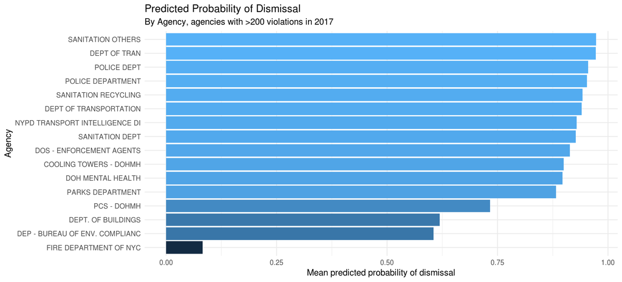

```r
pred_rf %>%
  sdf_separate_column("probability",c("not","dism")) %>%
  group_by(Issuing_Agency) %>%
  filter(!Issuing_Agency=='NA') %>%
  summarise(number=n(),
            dismissed=sum(Dismissed),
            mean_pred=mean(dism)) %>%
  collect() %>%
  arrange(-mean_pred) %>%
  filter(number>200) %>%
  ggplot(aes(reorder(Issuing_Agency,mean_pred),mean_pred))+
  geom_bar(aes(fill=mean_pred),stat='identity')+
  coord_flip()+
  labs(x='Agency',y='Mean predicted probability of dismissal',
       title='Predicted Probability of Dismissal',
       subtitle='By Agency, agencies with >200 violations in 2017')+
  theme_minimal()+
  theme(legend.position = 'none')
```

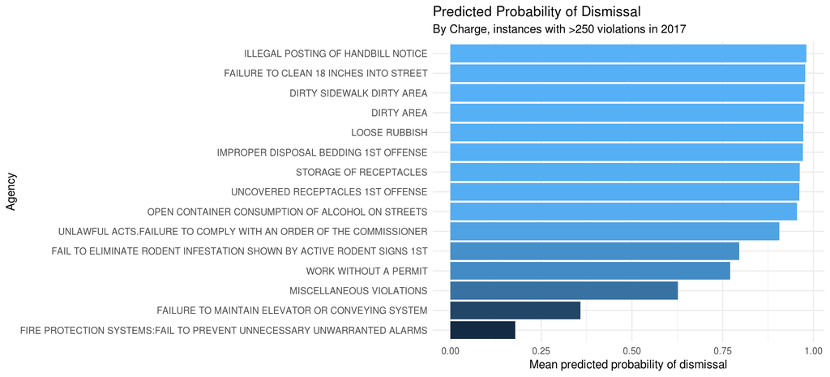

```r
pred_rf %>%
  sdf_separate_column("probability",c("not","dism")) %>%
  group_by(Charge_1_Code_Description) %>%
  filter(!Charge_1_Code_Description=='NA') %>%
  summarise(number=n(),
            dismissed=sum(Dismissed),
            mean_pred=mean(dism)) %>%
  collect() %>%
  arrange(-mean_pred) %>%
  filter(number>250) %>%
  dplyr::filter(row_number() %in% c(1:5) | row_number() %in% c(n()-5:n())) %>%
  ggplot(aes(reorder(Charge_1_Code_Description,mean_pred),mean_pred))+
  geom_bar(aes(fill=mean_pred),stat='identity')+
  coord_flip()+
  labs(x='Agency',y='Mean predicted probability of dismissal',
       title='Predicted Probability of Dismissal',
       subtitle='By Charge, instances with >250 violations in 2017')+
  theme_minimal()+
  theme(legend.position = 'none')
```

## Local Violations

```r
pred_rf %>%
  sdf_separate_column("probability",c("not","dism")) %>%
  filter(Violation_Location_Zip_Code=="11103") %>%
  group_by(Issuing_Agency) %>%
  summarise(number=n(),
            dismissed=sum(Dismissed),
            mean_pred=mean(dism)) %>%
  collect() %>%
  arrange(-number) %>%
  kable(caption='Astoria, NY (11103) 2017 OATH Violations') %>%
  kable_styling()
```

| Issuing_Agency | number | dismissed | mean_pred |
| --- | --- | --- | --- |
| FIRE DEPARTMENT OF NYC | 25 | 1 | 0.0467245 |
| SANITATION OTHERS | 21 | 21 | 0.9768424 |
| DOS - ENFORCEMENT AGENTS | 13 | 13 | 0.8583608 |
| DEPT. OF BUILDINGS | 7 | 3 | 0.5019854 |
| SANITATION DEPT | 5 | 4 | 0.8171349 |
| NA | 3 | 3 | 0.9654332 |
| DEP - BUREAU OF ENV. COMPLIANC | 1 | 0 | 0.3534729 |
| SANITATION POLICE | 1 | 1 | 0.8196780 |

## Conclusion

This was an interesting exercise that increased my knowledge of NYC summons processing, Spark, and machine learning pipelines. I now know my chances of beating my case at an OATH hearing!

# Timing

The running time of this file was 6.7605051 minutes.